# Timeseries Basics

Eric Bridgeford

October 5, 2016

## Loading in Your Data

As a new R user, users will immediately realize that, while somewhat intuitive, there are many quirks to R that can make entry not quite as smooth as other languages. The data formats are often moderately confusing at best, and often times as a beginner you are left out on your own sifting through CRAN manuals trying to figure out why there are 40 different ply functions and none of them do what you want. Rest assured, I’ve been there and done that, and hopefully with a little tutorial series you can get up to speed a lot faster than I did.

Let’s go through a few functions to see some exploratory analysis we can do with our timeseries. To begin, let’s load in some sample data. Our first dimension, here, is the brain region of interest, while the second is the timestep:

```r
  test = readRDS('test.rds')
  print(dim(test))
```

```
## [1]  70 240
```

Here, we can see that we have loaded some timeseries data. We have printed its dimensions, which are a vector in this case. To begin, let’s find some easy ways to visualize our data. To begin, we need to have a basic understanding of the ggplot2 framework, which requires some knowledge of the reshape framework as well.

### Reshape Overview

Essentially, the reshape framework provides R users a somewhat (read: not at all if you’re a beginner!) intuitive way to move between normal data types (ie, vectors, arrays, matrices, etc) and more R-specialized data types (ie, lists, data frames, etc). As our test is currently an array (70x240), to do any exploratory plotting, we need to get it into a format that ggplot knows how to use. In this case, that will be the data frame:

```r
  require('reshape2') # source the library
  data_frame_test = melt(test) # use the melt command to go from array to data frame
  names(data_frame_test) = c("ROI","Time", "Value") # change the data frame's column names
  print(data_frame_test[1:5,]) # print a subset of the data frame
```

```
##   ROI Time     Value
## 1   1    1  7.374717
## 2   2    1  7.255046
## 3   3    1 10.117655
## 4   4    1  6.265905
## 5   5    1  8.219137
```

Essentially, the melt function (part of reshape) will simply reduce our array dimension wise (ie, list all of the possible values of dimension 1 while dimension 2 is fixed at its first possible value, then list all of the possible values of dimension 1 while dimension 2 is fixed at its second possible value, and so on for all dimensions). Finally, it adds a column onto the end for the actual value that the array takes at the particular point specified. The name command, a feature of data frames, allows us to rename these columns for our respective dimensions/values to be something more intuitive. Here, we’ve renamed the columns to ROI, time, and value. Finally, we print a subset of the data frame, which should give you a better idea of how it works. If you need some more help, play around with printing larger segments.

Next, we’ll look at some ways to index data frames.

```r
  print(data_frame_test$ROI[1:5])
```

```
## [1] 1 2 3 4 5
```

Using the dollar sign let’s us index by columns in our data frame. Here, we print the ROI column, and the first five rows corresponding exactly to the ones we previously printed. In R, proper code organization should take advantage of these easy vector operations. R is optimized for matrix speed, and the more you exploit these seemingly simple observations the more you will realize how truly powerful R is.

Let’s look at a more complex example. First, let’s show that we can use these column operations for indexing:

```r
  print(which(data_frame_test$ROI == 1))
```

```
##   [1]     1    71   141   211   281   351   421   491   561   631   701
##  [12]   771   841   911   981  1051  1121  1191  1261  1331  1401  1471
##  [23]  1541  1611  1681  1751  1821  1891  1961  2031  2101  2171  2241
##  [34]  2311  2381  2451  2521  2591  2661  2731  2801  2871  2941  3011
##  [45]  3081  3151  3221  3291  3361  3431  3501  3571  3641  3711  3781
##  [56]  3851  3921  3991  4061  4131  4201  4271  4341  4411  4481  4551
##  [67]  4621  4691  4761  4831  4901  4971  5041  5111  5181  5251  5321
##  [78]  5391  5461  5531  5601  5671  5741  5811  5881  5951  6021  6091
##  [89]  6161  6231  6301  6371  6441  6511  6581  6651  6721  6791  6861
## [100]  6931  7001  7071  7141  7211  7281  7351  7421  7491  7561  7631
## [111]  7701  7771  7841  7911  7981  8051  8121  8191  8261  8331  8401
## [122]  8471  8541  8611  8681  8751  8821  8891  8961  9031  9101  9171
## [133]  9241  9311  9381  9451  9521  9591  9661  9731  9801  9871  9941
## [144] 10011 10081 10151 10221 10291 10361 10431 10501 10571 10641 10711
## [155] 10781 10851 10921 10991 11061 11131 11201 11271 11341 11411 11481
## [166] 11551 11621 11691 11761 11831 11901 11971 12041 12111 12181 12251
## [177] 12321 12391 12461 12531 12601 12671 12741 12811 12881 12951 13021
## [188] 13091 13161 13231 13301 13371 13441 13511 13581 13651 13721 13791
## [199] 13861 13931 14001 14071 14141 14211 14281 14351 14421 14491 14561
## [210] 14631 14701 14771 14841 14911 14981 15051 15121 15191 15261 15331
## [221] 15401 15471 15541 15611 15681 15751 15821 15891 15961 16031 16101
## [232] 16171 16241 16311 16381 16451 16521 16591 16661 16731
```

Here, we see that this returns the row ids that correspond to ROI == 1. Let’s look some more into how this works:

```r
  print(isTRUE(all.equal(length(which(data_frame_test$ROI == 1)), dim(test)[2])))
```

```
## [1] TRUE
```

Here, we see that we can find exactly which rows of our data frame have corresponding column ROI ids of 1 (there is 1 observation per roi per timestep, so we expect to have a number of rows equal to the number of timesteps). We can chain this column indexing together to subset our data, like this:

```r
  print(isTRUE(all.equal(data_frame_test[which(data_frame_test$ROI == 4 & data_frame_test$Time == 5),]$Value, test[4,5])))
```

```
## [1] TRUE
```

Here, we’ve essentially showed that our melt does exactly what we said a few minutes ago. We have indexed by both our ROI and Time column, and show that it equals those of our initial input matrix. Compared to a language like python, this makes R code incredibly user friendly and readable once you get up to speed (even if it seems odd now, I promise it gets a lot better). In this example, we simply indexed by the ROIs (which gave us a vector of booleans) and then separately indexed by Timestep (giving us another vector of booleans), and then & them together to get their intersection, and finally get the value of this row of the data frame. We can take large subsets of the data in this way, and can very intuitively break it apart in a readable format (majorly contrasting from most languages). Now, let’s try some exploratory analysis, now that we have a slight footing on how the data organization works.

Let’s try making a line plot:

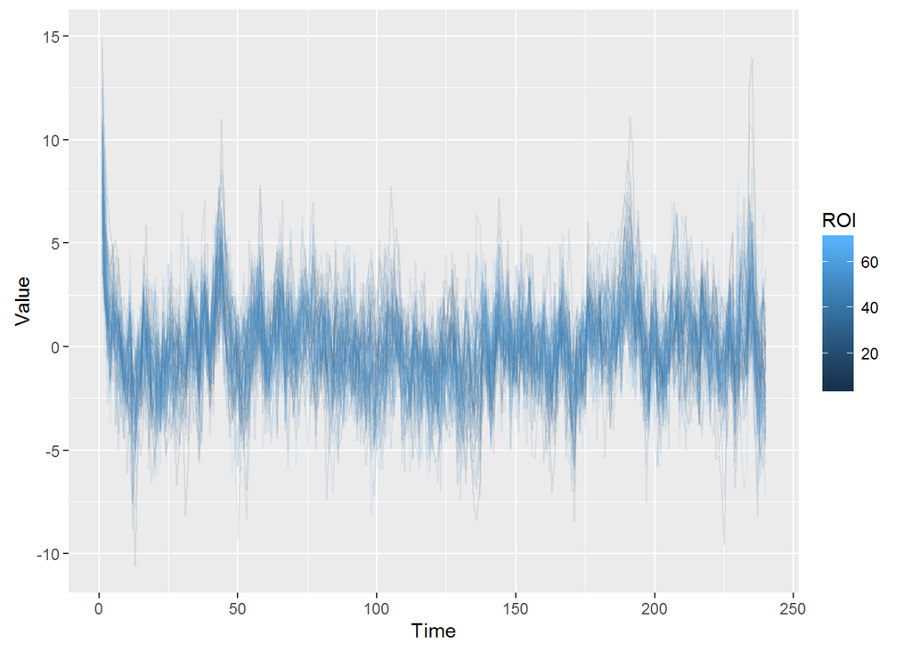

```r
  require('ggplot2')
  ggplot(data=data_frame_test, aes(x=Time, y=Value, group=ROI, colour=ROI)) +
      geom_line(alpha=.1)
```

Fortunately, ggplot knows how to work with our data frames in a very structured manner. With this simple command, we’ve passed our y axis label, our x axis label, and our legend, as well as created lines for each ROI, simply using the data frame methodology (essentially, you are just passing the column names that you want to regress out for you x, y, group, etc “aesthetics” of your plot). Next, we’ll wrap this in a function, this time taking the original vector:

```r
lineplot <- function(ts, type, xlabel, groupname) {
  return(ggplot(data=melt(ts), aes(x=Var2, y=value, group=Var1, color=Var1)) +
      geom_line(alpha=.1) +
      scale_y_continuous(limits=c(min(ts), max(ts))) +
      ylab(type) +
      xlab(xlabel) +
      ggtitle(paste(type, "for each ROI", sep=" ")) +
      theme(legend.title=element_text(paste(groupname))))
}
```

I’ll leave it to you to look up each individual function, but here we inline our melt so that when we call the function in the future, we don’t need to pre-melt and adjust our data frame. We make our x, y, and group level aesthetics the defaults for what our item would melt to (you can check what the column names would default to with print(melt(ts)[1,])) and they will be listed at the top).

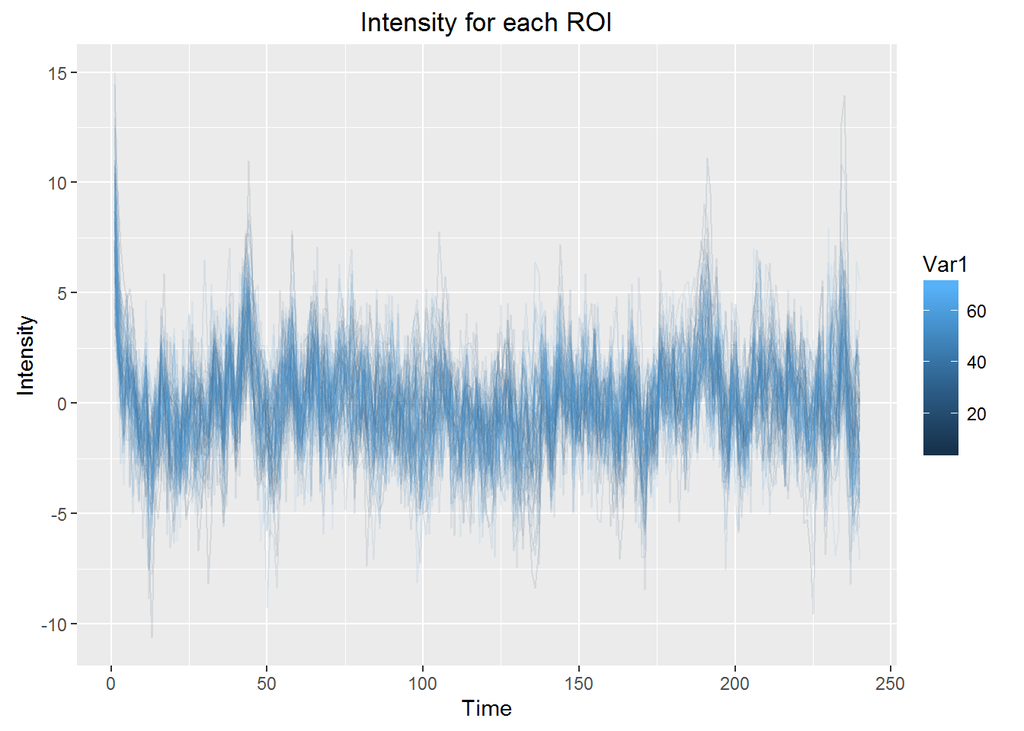

```r
  lineplot(test, type="Intensity", xlab="Time", groupname="ROI")
```

## Correlation Matrix Plotting

Finally, let’s look at how to make a simple correlation matrix.

We use the cor function in R, and note by consulting its manual that it returns the correlation coefficients between the second dimension elements of our input vector. Therefore, because we want the correlations with respect to our first dimension of our test data, we must use the transpose:

```r
  testcor <- cor(t(test)) # correlation of the transpose
```

Finally, we define our correlation matrix function. We use a similar method to our inlined line plot, however, here we also have a fill for the correlation coefficient of each edge.

```r
plot_one_mtx <- function(mtx, textsize=10) {
  return(ggplot(data = melt(mtx), aes(x=Var1, y=Var2, fill=value)) +
           geom_tile(color="white") +
           scale_x_continuous("ROI", breaks=c(1, as.integer(dim(mtx)[1]/2), as.integer(dim(mtx)[1]))) +
           scale_y_continuous("ROI", breaks=c(1, as.integer(dim(mtx)[2]/2), as.integer(dim(mtx)[2])), trans="reverse") +
           scale_fill_gradientn(colours=c("blue","green","yellow","orange","red")) +
           theme(text=element_text(size=textsize)))
}
```

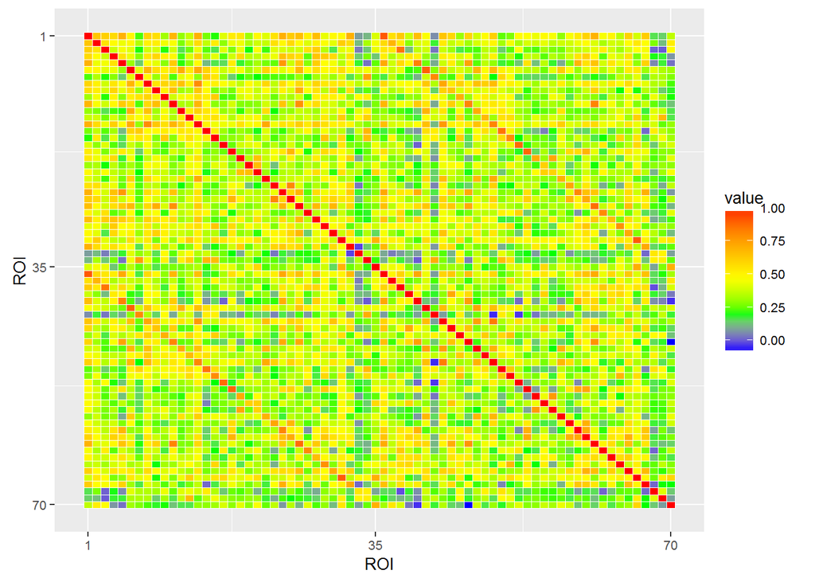

```r
  print(plot_one_mtx(testcor))
```

## Generalized Heat Map

Sometimes, it is useful to view our timeseries data itself as a heat map. In many aspects of neuroscience, for instance, researchers will look at EEG data as a heat map, as they feel this provides more insight into the data than otherwise. Here, we can think of the heat map essentially as just viewing the data on a different plane (Consider all of the lines being right next to each other laterally going into the z axis, and then you simply change axes such that you are looking at the z axis with respect to your original x axis, and you are now looking down on your values). Your values now are intensity scored to a color.

```r
heat <- function(ts, type, xlabel, ylabel, textsize=10) {
  return(ggplot(data=melt(ts), aes(x=Var2, y=Var1, fill=value)) +
      geom_tile(color="white") +
      scale_fill_gradientn(colors=c("red", "green", "blue"), name=type, limits=c(min(ts), max(ts))) +
      scale_y_continuous(breaks=c(1,ceiling(dim(ts)[1]/2), dim(ts)[1])) + # comment here
      ylab(ylabel) +
      xlab(xlabel) +
      ggtitle(paste(type, "for each ROI", sep=" ")) +
      theme(legend.title=element_text(type)))
}
```

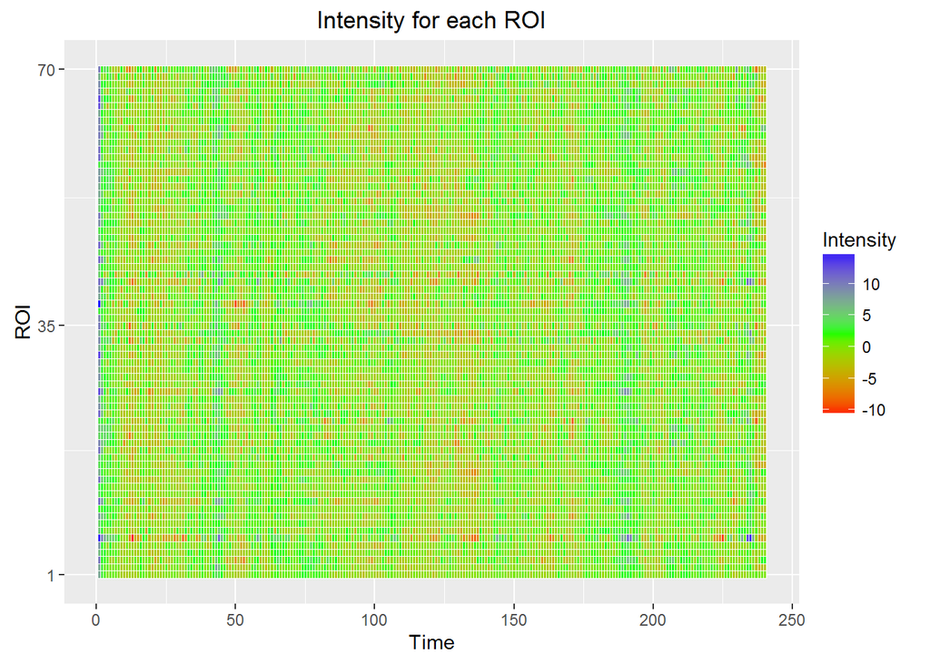

```r
  heat(test, type="Intensity", "Time", "ROI")
```

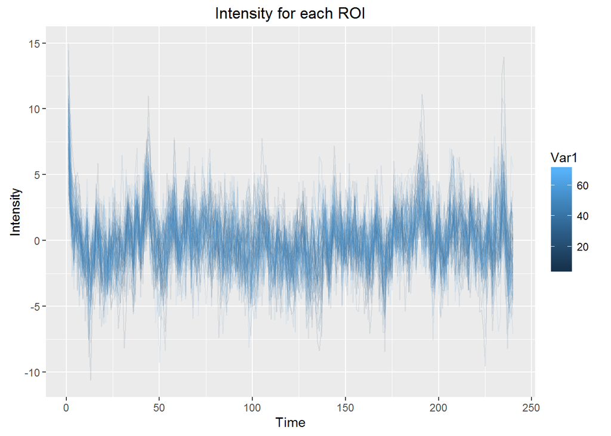

```r
  lineplot(test, type="Intensity", xlab="Time", groupname="ROI")
```